```python
import pandas as pd
import numpy as np
import re
import seaborn as sns
import matplotlib.pyplot as plt
import plotly.express as px
import matplotlib
!pip install wordcloud
from wordcloud import WordCloud
from scipy.stats import ttest_ind
from scipy import stats
```

# Шаг 1. Выбор темы проекта

Мы решили взять в качестве исследования готовый датасет "Top 1000 Highest Grossing Movies". Данные датасета являются актуальными и последний раз были обновлены 10 января 2022 года. Эти данные были собраны с нескольких сайтов и объединены для выполнения различных операций с данными. Данные были взяты с imdb, rotten tomatoes и многих других сайтов. В данном случае мы исследуем различные зависимости переменных друг от друга.

# Шаг 2. Сбор данных

```python
data = pd.read_csv('h.csv')
data.head(10)
```

|  | Unnamed: 0 | Title | Movie Info | Distributor | Release Date | Domestic Sales (in $) | International Sales (in $) | World Sales (in $) | Genre | Movie Runtime | License |
| --- | --- | --- | --- | --- | --- | --- | --- | --- | --- | --- | --- |
| 0 | 0 | Star Wars: Episode VII - The Force Awakens (2015) | As a new threat to the galaxy rises, Rey, a de... | Walt Disney Studios Motion Pictures | December 16, 2015 | 936662225 | 1132859475 | 2069521700 | ['Action', 'Adventure', 'Sci-Fi'] | 2 hr 18 min | PG-13 |
| 1 | 1 | Avengers: Endgame (2019) | After the devastating events of Avengers: Infi... | Walt Disney Studios Motion Pictures | April 24, 2019 | 858373000 | 1939128328 | 2797501328 | ['Action', 'Adventure', 'Drama', 'Sci-Fi'] | 3 hr 1 min | PG-13 |
| 2 | 2 | Avatar (2009) | A paraplegic Marine dispatched to the moon Pan... | Twentieth Century Fox | December 16, 2009 | 760507625 | 2086738578 | 2847246203 | ['Action', 'Adventure', 'Fantasy', 'Sci-Fi'] | 2 hr 42 min | PG-13 |
| 3 | 3 | Black Panther (2018) | T'Challa, heir to the hidden but advanced king... | Walt Disney Studios Motion Pictures | NaN | 700426566 | 647171407 | 1347597973 | ['Action', 'Adventure', 'Sci-Fi'] | 2 hr 14 min | NaN |
| 4 | 4 | Avengers: Infinity War (2018) | The Avengers and their allies must be willing ... | Walt Disney Studios Motion Pictures | NaN | 678815482 | 1369544272 | 2048359754 | ['Action', 'Adventure', 'Sci-Fi'] | 2 hr 29 min | NaN |
| 5 | 5 | Spider-Man: No Way Home (2021) | With Spider-Man's identity now revealed, Peter... | Sony Pictures Entertainment (SPE) | NaN | 675813257 | 868642706 | 1544455963 | ['Action', 'Adventure', 'Fantasy', 'Sci-Fi'] | 2 hr 28 min | NaN |
| 6 | 6 | Titanic (1997) | A seventeen-year-old aristocrat falls in love ... | Paramount Pictures | December 19, 1997 | 659363944 | 1542283320 | 2201647264 | ['Drama', 'Romance'] | 3 hr 14 min | PG-13 |
| 7 | 7 | Jurassic World (2015) | A new theme park, built on the original site o... | Universal Pictures | June 10, 2015 | 652385625 | 1018130819 | 1670516444 | ['Action', 'Adventure', 'Sci-Fi'] | 2 hr 4 min | PG-13 |
| 8 | 8 | The Avengers (2012) | Earth's mightiest heroes must come together an... | Walt Disney Studios Motion Pictures | April 25, 2012 | 623357910 | 895457605 | 1518815515 | ['Action', 'Adventure', 'Sci-Fi'] | 2 hr 23 min | PG-13 |
| 9 | 9 | Star Wars: Episode VIII - The Last Jedi (2017) | The Star Wars saga continues as new heroes and... | Walt Disney Studios Motion Pictures | December 13, 2017 | 620181382 | 712517448 | 1332698830 | ['Action', 'Adventure', 'Fantasy', 'Sci-Fi'] | 2 hr 32 min | PG-13 |

# Шаг 3. Предобработка данных

```python
# Выведем количество колонок и столбцов
def rows_and_cols(value):
    row = data.shape[0]
    col = data.shape[1]
    print(f"The dataset contains {row} rows and {col} columns")

rows_and_cols(data.head)
```

```
The dataset contains 918 rows and 11 columns
```

```python
# информация
def info(value):
    info = data.info()
    return info
info(data.head)
```

```
<class 'pandas.core.frame.DataFrame'>
RangeIndex: 918 entries, 0 to 917
Data columns (total 11 columns):
 #   Column                      Non-Null Count  Dtype
---  ------                      --------------  -----
 0   Unnamed: 0                  918 non-null    int64
 1   Title                       918 non-null    object
 2   Movie Info                  918 non-null    object
 3   Distributor                 918 non-null    object
 4   Release Date                800 non-null    object
 5   Domestic Sales (in $)       918 non-null    int64
 6   International Sales (in $)  918 non-null    int64
 7   World Sales (in $)          918 non-null    int64
 8   Genre                       918 non-null    object
 9   Movie Runtime               918 non-null    object
 10  License                     744 non-null    object
dtypes: int64(4), object(7)
memory usage: 79.0+ KB
```

```python
# проверка максимального и минимального значений описания
def des(vale):
    des = data.describe()
    return des
des(data.head)
```

|  | Unnamed: 0 | Domestic Sales (in $) | International Sales (in $) | World Sales (in $) |
| --- | --- | --- | --- | --- |
| count | 918.000000 | 9.180000e+02 | 9.180000e+02 | 9.180000e+02 |
| mean | 458.500000 | 1.677469e+08 | 2.301434e+08 | 3.968668e+08 |
| std | 265.148072 | 1.040360e+08 | 2.176011e+08 | 3.082629e+08 |
| min | 0.000000 | 8.036084e+07 | 2.600000e+02 | 8.160000e+07 |
| 25% | 229.250000 | 1.016071e+08 | 8.845620e+07 | 2.005564e+08 |
| 50% | 458.500000 | 1.321351e+08 | 1.638819e+08 | 3.019416e+08 |
| 75% | 687.750000 | 1.913905e+08 | 2.885577e+08 | 4.750718e+08 |
| max | 917.000000 | 9.366622e+08 | 2.086739e+09 | 2.847246e+09 |

## 1. Переведем значения в колонке длительности фильмов (Movie Runtime) на минуты.

```python
# Function to convert runtime format to minutes
def change_time(time_str):
    if isinstance(time_str, str):
        parts = time_str.split()
        if len(parts) == 4:
            hours = int(parts[0])
            minutes = int(parts[2])
            total_minutes = hours * 60 + minutes
            return total_minutes
        elif len(parts) == 2:
            if parts[1] == 'min':
                minutes = int(parts[0])
                return minutes
    return 0

# Create a new column 'Runtime (in minutes)' and fill it with the converted values
data['Movie Runtime (min)'] = data['Movie Runtime'].apply(change_time)

# Drop the original 'Movie Runtime' column
data = data.drop('Movie Runtime', axis=1)
data
```

|  | Unnamed: 0 | Title | Movie Info | Distributor | Release Date | Domestic Sales (in $) | International Sales (in $) | World Sales (in $) | Genre | License | Movie Runtime (min) |
| --- | --- | --- | --- | --- | --- | --- | --- | --- | --- | --- | --- |
| 0 | 0 | Star Wars: Episode VII - The Force Awakens (2015) | As a new threat to the galaxy rises, Rey, a de... | Walt Disney Studios Motion Pictures | December 16, 2015 | 936662225 | 1132859475 | 2069521700 | ['Action', 'Adventure', 'Sci-Fi'] | PG-13 | 138 |
| 1 | 1 | Avengers: Endgame (2019) | After the devastating events of Avengers: Infi... | Walt Disney Studios Motion Pictures | April 24, 2019 | 858373000 | 1939128328 | 2797501328 | ['Action', 'Adventure', 'Drama', 'Sci-Fi'] | PG-13 | 181 |
| 2 | 2 | Avatar (2009) | A paraplegic Marine dispatched to the moon Pan... | Twentieth Century Fox | December 16, 2009 | 760507625 | 2086738578 | 2847246203 | ['Action', 'Adventure', 'Fantasy', 'Sci-Fi'] | PG-13 | 162 |
| 3 | 3 | Black Panther (2018) | T'Challa, heir to the hidden but advanced king... | Walt Disney Studios Motion Pictures | NaN | 700426566 | 647171407 | 1347597973 | ['Action', 'Adventure', 'Sci-Fi'] | NaN | 134 |
| 4 | 4 | Avengers: Infinity War (2018) | The Avengers and their allies must be willing ... | Walt Disney Studios Motion Pictures | NaN | 678815482 | 1369544272 | 2048359754 | ['Action', 'Adventure', 'Sci-Fi'] | NaN | 149 |
| ... | ... | ... | ... | ... | ... | ... | ... | ... | ... | ... | ... |
| 913 | 913 | The Notebook (2004) | A poor yet passionate young man falls in love ... | New Line Cinema | June 25, 2004 | 81001787 | 36813370 | 117815157 | ['Drama', 'Romance'] | PG-13 | 123 |
| 914 | 914 | Jimmy Neutron: Boy Genius (2001) | An eight-year-old boy genius and his friends m... | Paramount Pictures | December 21, 2001 | 80936232 | 22056304 | 102992536 | ['Action', 'Adventure', 'Animation', 'Comedy',... | NaN | 82 |
| 915 | 915 | Eat Pray Love (2010) | A married woman realizes how unhappy her marri... | Sony Pictures Entertainment (SPE) | August 13, 2010 | 80574010 | 124020006 | 204594016 | ['Biography', 'Drama', 'Romance'] | PG-13 | 133 |
| 916 | 916 | The Texas Chainsaw Massacre (2003) | After picking up a traumatized young hitchhike... | New Line Cinema | October 17, 2003 | 80571655 | 26792250 | 107363905 | ['Crime', 'Horror'] | R | 98 |
| 917 | 917 | Zookeeper (2011) | A group of zoo animals decide to break their c... | Sony Pictures Entertainment (SPE) | July 6, 2011 | 80360843 | 89491916 | 169852759 | ['Comedy', 'Family', 'Fantasy', 'Romance'] | PG | 102 |

918 rows × 11 columns

## 2. Запишем в колонке с жанрами главный из перечисленных для каждого фильма:

```python
import pandas as pd
import ast

# Функция для извлечения первого жанра
def extract_main_genre(genre_list):
    if isinstance(genre_list, list) and len(genre_list) > 0:
        return genre_list[0]
    elif isinstance(genre_list, str):
        try:
            genre_parts = ast.literal_eval(genre_list)
            if isinstance(genre_parts, list) and len(genre_parts) > 0:
                return genre_parts[0]
        except ValueError:
            pass
    return None

# Создание новой колонки 'Main Genre' с первым жанром
data['Main Genre'] = data['Genre'].apply(extract_main_genre)
data
```

|  | Unnamed: 0 | Title | Movie Info | Distributor | Release Date | Domestic Sales (in $) | International Sales (in $) | World Sales (in $) | Genre | License | Movie Runtime (min) | Main Genre |
| --- | --- | --- | --- | --- | --- | --- | --- | --- | --- | --- | --- | --- |
| 0 | 0 | Star Wars: Episode VII - The Force Awakens (2015) | As a new threat to the galaxy rises, Rey, a de... | Walt Disney Studios Motion Pictures | December 16, 2015 | 936662225 | 1132859475 | 2069521700 | ['Action', 'Adventure', 'Sci-Fi'] | PG-13 | 138 | Action |
| 1 | 1 | Avengers: Endgame (2019) | After the devastating events of Avengers: Infi... | Walt Disney Studios Motion Pictures | April 24, 2019 | 858373000 | 1939128328 | 2797501328 | ['Action', 'Adventure', 'Drama', 'Sci-Fi'] | PG-13 | 181 | Action |
| 2 | 2 | Avatar (2009) | A paraplegic Marine dispatched to the moon Pan... | Twentieth Century Fox | December 16, 2009 | 760507625 | 2086738578 | 2847246203 | ['Action', 'Adventure', 'Fantasy', 'Sci-Fi'] | PG-13 | 162 | Action |
| 3 | 3 | Black Panther (2018) | T'Challa, heir to the hidden but advanced king... | Walt Disney Studios Motion Pictures | NaN | 700426566 | 647171407 | 1347597973 | ['Action', 'Adventure', 'Sci-Fi'] | NaN | 134 | Action |
| 4 | 4 | Avengers: Infinity War (2018) | The Avengers and their allies must be willing ... | Walt Disney Studios Motion Pictures | NaN | 678815482 | 1369544272 | 2048359754 | ['Action', 'Adventure', 'Sci-Fi'] | NaN | 149 | Action |
| ... | ... | ... | ... | ... | ... | ... | ... | ... | ... | ... | ... | ... |
| 913 | 913 | The Notebook (2004) | A poor yet passionate young man falls in love ... | New Line Cinema | June 25, 2004 | 81001787 | 36813370 | 117815157 | ['Drama', 'Romance'] | PG-13 | 123 | Drama |
| 914 | 914 | Jimmy Neutron: Boy Genius (2001) | An eight-year-old boy genius and his friends m... | Paramount Pictures | December 21, 2001 | 80936232 | 22056304 | 102992536 | ['Action', 'Adventure', 'Animation', 'Comedy',... | NaN | 82 | Action |
| 915 | 915 | Eat Pray Love (2010) | A married woman realizes how unhappy her marri... | Sony Pictures Entertainment (SPE) | August 13, 2010 | 80574010 | 124020006 | 204594016 | ['Biography', 'Drama', 'Romance'] | PG-13 | 133 | Biography |
| 916 | 916 | The Texas Chainsaw Massacre (2003) | After picking up a traumatized young hitchhike... | New Line Cinema | October 17, 2003 | 80571655 | 26792250 | 107363905 | ['Crime', 'Horror'] | R | 98 | Crime |
| 917 | 917 | Zookeeper (2011) | A group of zoo animals decide to break their c... | Sony Pictures Entertainment (SPE) | July 6, 2011 | 80360843 | 89491916 | 169852759 | ['Comedy', 'Family', 'Fantasy', 'Romance'] | PG | 102 | Comedy |

918 rows × 12 columns

## 3. Перепишем колонку с датой выпуска фильмов, заменив полную дату на год:

```python
# Извлечение года из полной даты
data['Release Year'] = data['Release Date'].str[-4:]

# Удаление старой колонки 'Release Date'
data = data.drop('Release Date', axis=1)
data
```

|  | Unnamed: 0 | Title | Movie Info | Distributor | Domestic Sales (in $) | International Sales (in $) | World Sales (in $) | Genre | License | Movie Runtime (min) | Main Genre | Release Year |
| --- | --- | --- | --- | --- | --- | --- | --- | --- | --- | --- | --- | --- |
| 0 | 0 | Star Wars: Episode VII - The Force Awakens (2015) | As a new threat to the galaxy rises, Rey, a de... | Walt Disney Studios Motion Pictures | 936662225 | 1132859475 | 2069521700 | ['Action', 'Adventure', 'Sci-Fi'] | PG-13 | 138 | Action | 2015 |
| 1 | 1 | Avengers: Endgame (2019) | After the devastating events of Avengers: Infi... | Walt Disney Studios Motion Pictures | 858373000 | 1939128328 | 2797501328 | ['Action', 'Adventure', 'Drama', 'Sci-Fi'] | PG-13 | 181 | Action | 2019 |
| 2 | 2 | Avatar (2009) | A paraplegic Marine dispatched to the moon Pan... | Twentieth Century Fox | 760507625 | 2086738578 | 2847246203 | ['Action', 'Adventure', 'Fantasy', 'Sci-Fi'] | PG-13 | 162 | Action | 2009 |
| 3 | 3 | Black Panther (2018) | T'Challa, heir to the hidden but advanced king... | Walt Disney Studios Motion Pictures | 700426566 | 647171407 | 1347597973 | ['Action', 'Adventure', 'Sci-Fi'] | NaN | 134 | Action | NaN |
| 4 | 4 | Avengers: Infinity War (2018) | The Avengers and their allies must be willing ... | Walt Disney Studios Motion Pictures | 678815482 | 1369544272 | 2048359754 | ['Action', 'Adventure', 'Sci-Fi'] | NaN | 149 | Action | NaN |
| ... | ... | ... | ... | ... | ... | ... | ... | ... | ... | ... | ... | ... |
| 913 | 913 | The Notebook (2004) | A poor yet passionate young man falls in love ... | New Line Cinema | 81001787 | 36813370 | 117815157 | ['Drama', 'Romance'] | PG-13 | 123 | Drama | 2004 |
| 914 | 914 | Jimmy Neutron: Boy Genius (2001) | An eight-year-old boy genius and his friends m... | Paramount Pictures | 80936232 | 22056304 | 102992536 | ['Action', 'Adventure', 'Animation', 'Comedy',... | NaN | 82 | Action | 2001 |
| 915 | 915 | Eat Pray Love (2010) | A married woman realizes how unhappy her marri... | Sony Pictures Entertainment (SPE) | 80574010 | 124020006 | 204594016 | ['Biography', 'Drama', 'Romance'] | PG-13 | 133 | Biography | 2010 |
| 916 | 916 | The Texas Chainsaw Massacre (2003) | After picking up a traumatized young hitchhike... | New Line Cinema | 80571655 | 26792250 | 107363905 | ['Crime', 'Horror'] | R | 98 | Crime | 2003 |
| 917 | 917 | Zookeeper (2011) | A group of zoo animals decide to break their c... | Sony Pictures Entertainment (SPE) | 80360843 | 89491916 | 169852759 | ['Comedy', 'Family', 'Fantasy', 'Romance'] | PG | 102 | Comedy | 2011 |

918 rows × 12 columns

```python
# Функция для извлечения года из названия фильма
def extract_year_from_title(title):
    pattern = r'\((\d{4})\)'  # Регулярное выражение для поиска года в скобках
    match = re.search(pattern, title)
    if match:
        return match.group(1)
    return None

# Замена NaN значениями года из названия фильма
data['Release Year'] = data.apply(lambda row: row['Release Year'] if pd.notna(row['Release Year']) else extract_year_from_title(row['Title']), axis=1)
data
```

|  | Unnamed: 0 | Title | Movie Info | Distributor | Domestic Sales (in $) | International Sales (in $) | World Sales (in $) | Genre | License | Movie Runtime (min) | Main Genre | Release Year |
| --- | --- | --- | --- | --- | --- | --- | --- | --- | --- | --- | --- | --- |
| 0 | 0 | Star Wars: Episode VII - The Force Awakens (2015) | As a new threat to the galaxy rises, Rey, a de... | Walt Disney Studios Motion Pictures | 936662225 | 1132859475 | 2069521700 | ['Action', 'Adventure', 'Sci-Fi'] | PG-13 | 138 | Action | 2015 |
| 1 | 1 | Avengers: Endgame (2019) | After the devastating events of Avengers: Infi... | Walt Disney Studios Motion Pictures | 858373000 | 1939128328 | 2797501328 | ['Action', 'Adventure', 'Drama', 'Sci-Fi'] | PG-13 | 181 | Action | 2019 |
| 2 | 2 | Avatar (2009) | A paraplegic Marine dispatched to the moon Pan... | Twentieth Century Fox | 760507625 | 2086738578 | 2847246203 | ['Action', 'Adventure', 'Fantasy', 'Sci-Fi'] | PG-13 | 162 | Action | 2009 |
| 3 | 3 | Black Panther (2018) | T'Challa, heir to the hidden but advanced king... | Walt Disney Studios Motion Pictures | 700426566 | 647171407 | 1347597973 | ['Action', 'Adventure', 'Sci-Fi'] | NaN | 134 | Action | 2018 |
| 4 | 4 | Avengers: Infinity War (2018) | The Avengers and their allies must be willing ... | Walt Disney Studios Motion Pictures | 678815482 | 1369544272 | 2048359754 | ['Action', 'Adventure', 'Sci-Fi'] | NaN | 149 | Action | 2018 |
| ... | ... | ... | ... | ... | ... | ... | ... | ... | ... | ... | ... | ... |
| 913 | 913 | The Notebook (2004) | A poor yet passionate young man falls in love ... | New Line Cinema | 81001787 | 36813370 | 117815157 | ['Drama', 'Romance'] | PG-13 | 123 | Drama | 2004 |
| 914 | 914 | Jimmy Neutron: Boy Genius (2001) | An eight-year-old boy genius and his friends m... | Paramount Pictures | 80936232 | 22056304 | 102992536 | ['Action', 'Adventure', 'Animation', 'Comedy',... | NaN | 82 | Action | 2001 |
| 915 | 915 | Eat Pray Love (2010) | A married woman realizes how unhappy her marri... | Sony Pictures Entertainment (SPE) | 80574010 | 124020006 | 204594016 | ['Biography', 'Drama', 'Romance'] | PG-13 | 133 | Biography | 2010 |
| 916 | 916 | The Texas Chainsaw Massacre (2003) | After picking up a traumatized young hitchhike... | New Line Cinema | 80571655 | 26792250 | 107363905 | ['Crime', 'Horror'] | R | 98 | Crime | 2003 |
| 917 | 917 | Zookeeper (2011) | A group of zoo animals decide to break their c... | Sony Pictures Entertainment (SPE) | 80360843 | 89491916 | 169852759 | ['Comedy', 'Family', 'Fantasy', 'Romance'] | PG | 102 | Comedy | 2011 |

918 rows × 12 columns

# Шаг 4. Визуализация EDA

```python
genre = data['Main Genre'].unique() #выведем список жанров
genre
```

```
array(['Action', 'Drama', 'Adventure', 'Crime', 'Horror', 'Comedy',
       'Animation', 'Biography', 'Mystery', 'Documentary', 'Fantasy'],
      dtype=object)
```

```python
data['Main Genre'].value_counts() #выведем табличку с жанрами и количеством фильмов у каждого
```

```
Action         396
Adventure      184
Comedy         166
Drama           72
Crime           33
Biography       32
Horror          23
Animation        6
Fantasy          3
Mystery          2
Documentary      1
Name: Main Genre, dtype: int64
```

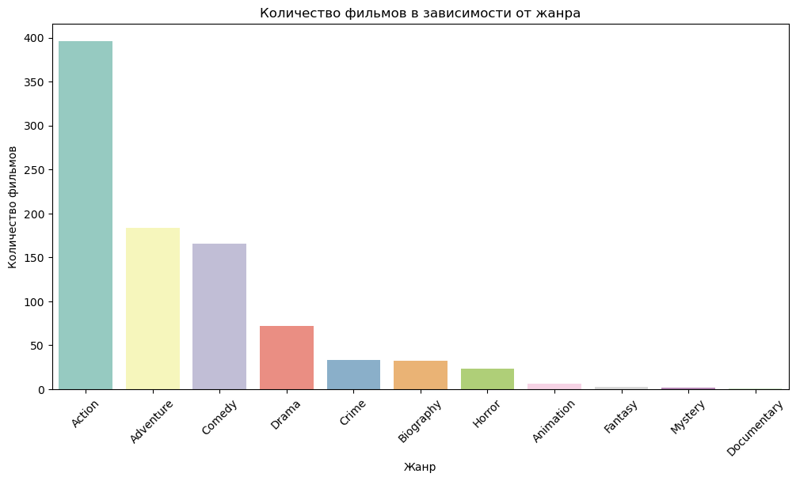

```python
# Подсчет количества фильмов по жанрам
genre_counts = data['Main Genre'].value_counts()

# Визуализация
plt.figure(figsize=(12, 6))
sns.barplot(x=genre_counts.index, y=genre_counts.values, palette='Set3')
plt.xticks(rotation=45)
plt.xlabel('Жанр')
plt.ylabel('Количество фильмов')
plt.title('Количество фильмов в зависимости от жанра')
plt.show()
```

Можем заметить, что больше всего фильмов имеет жанр Action, примерно одинаковое количество у жанров Adventure и Comedy, также можем увидеть,что жанры Animation, Fantasy, Mystery, Documentary почти не пользуются популярностью

```python
# Подсчет количества фильмов для каждого дистрибьютора
distributors = data['Distributor'].value_counts()
distributors
```

```
Warner Bros.                           158
Walt Disney Studios Motion Pictures    155
Universal Pictures                     119
Twentieth Century Fox                  117
Sony Pictures Entertainment (SPE)      101
Paramount Pictures                      99
DreamWorks                              21
New Line Cinema                         21
Lionsgate                               19
DreamWorks Distribution                 17
Metro-Goldwyn-Mayer (MGM)               12
TriStar Pictures                         9
Miramax                                  9
Revolution Studios                       8
Columbia Pictures                        7
Dimension Films                          7
The Weinstein Company                    6
Summit Entertainment                     5
Fox Searchlight Pictures                 4
STX Entertainment                        3
Orion Pictures                           3
Screen Gems                              3
United Artists                           2
Focus Features                           2
FilmDistrict                             2
Relativity Media                         1
United Artists Releasing                 1
IFC Films                                1
20th Century Studios                     1
USA Films                                1
Sony Pictures Classics                   1
Artisan Entertainment                    1
Newmarket Films                          1
Roadside Attractions                     1
Name: Distributor, dtype: int64
```

```python
# Вывод топ-10 дистрибьюторов
top_10_distributors = distributors.head(10)
top_10_distributors
```

```
Warner Bros.                           158
Walt Disney Studios Motion Pictures    155
Universal Pictures                     119
Twentieth Century Fox                  117
Sony Pictures Entertainment (SPE)      101
Paramount Pictures                      99
DreamWorks                              21
New Line Cinema                         21
Lionsgate                               19
DreamWorks Distribution                 17
Name: Distributor, dtype: int64
```

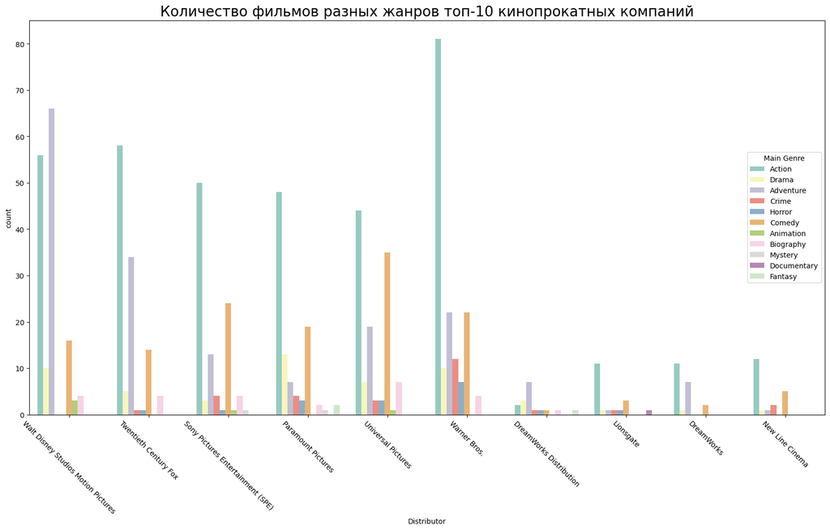

```python
top_10_distributors_list = top_10_distributors.index.tolist()

# Фильтрация данных для топ-10 дистрибьюторов
filtered_data = data[data['Distributor'].isin(top_10_distributors_list)]

# Визуализация
plt.figure(figsize=(20, 10))
sns.countplot(data=filtered_data, x='Distributor', hue='Main Genre', palette='Set3')
plt.xticks(rotation=-45)
plt.title('Количество фильмов разных жанров топ-10 кинопрокатных компаний', fontsize=20)
plt.legend(title='Main Genre', loc='center right')
plt.show()
```

### Из графика можно сделать следующие выводы:

- Наиболее массово производят фильмы следующие кинокомпании: Warner Bros, Walt Disney Studios Motion Pictures, Universal Pictures, Twentieth Century Fox, Sony Pictures Entertainment (SPE), Paramount Pictures. Они производят значительно больше фильмов по сравнению с другими дистрибьюторами.
- Наиболее популярными жанрами являются "Action", "Adventure", "Comedy" и "Drama".
- Некоторые дистрибьюторы, такие как "Warner Bros.", "Walt Disney Studios Motion Pictures" сконцентрированы на определенных жанрах, в данном случае - "Action" и "Adventure" соответственно.

```python
# Создание нового столбца 'Duration Group' на основе длительности фильмов
bins = [0, 75, 90, 105, 120, 135, 150, 180, float('inf')]
labels = ['<=75', '76-90', '91-105', '106-120', '121-135', '136-150', '151-180', '>180']
data['Duration Group'] = pd.cut(data['Movie Runtime (min)'], bins=bins, labels=labels, right=False)

# Группировка данных по 'Duration Group' и подсчет количества фильмов
grouped_data = data.groupby('Duration Group').size().reset_index(name='Count')


# Вывод таблицы
print(grouped_data)
```

```
  Duration Group  Count
0           <=75     18
1          76-90     63
2         91-105    226
3        106-120    256
4        121-135    187
5        136-150    107
6        151-180     53
7           >180      8
```

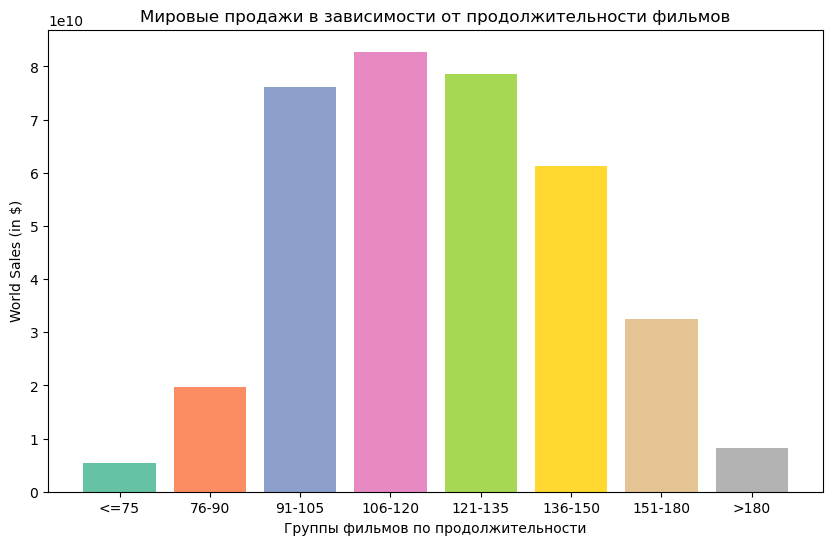

```python
# Группировка данных по 'Duration Group' и суммирование показателя 'World Sales'
grouped_data_with_Sales = data.groupby('Duration Group')['World Sales (in $)'].sum().reset_index()

palette = sns.color_palette("Set2")

# Визуализация данных
plt.figure(figsize=(10, 6))
plt.bar(grouped_data_with_Sales['Duration Group'], grouped_data_with_Sales['World Sales (in $)'], color=palette)
plt.xlabel('Группы фильмов по продолжительности')
plt.ylabel('World Sales (in $)')
plt.title('Мировые продажи в зависимости от продолжительности фильмов')
plt.show()
```

**Вывод:** Можем заметить, что больше всего объемов продаж приходится на фильмы длительности от полутора часов до двух часов 15 минут.

```python
# Группировка данных по жанру и суммирование показателя 'World Sales'
genre_sales = data.groupby('Main Genre')['World Sales (in $)'].sum().reset_index()

# Вычисление процентного соотношения продаж для каждого жанра
genre_sales['Percentage'] = genre_sales['World Sales (in $)'] / genre_sales['World Sales (in $)'].sum() * 100

# Создание круговой диаграммы с использованием Plotly Express
fig = px.pie(genre_sales, values='Percentage', names='Main Genre', color_discrete_sequence=px.colors.qualitative.Set2)

# Настройка внешнего вида диаграммы
fig.update_traces(textposition='inside', textinfo='percent+label')

# Наименование диаграммы
fig.update_layout(title='Процент разных жанров в общем объеме мировых продаж', title_x=0.45)

# Отображение диаграммы
fig.show()
```

[interactive chart not shown]

**Вывод:** Таким образом, большую часть мировых продаж в датасете составляет жанр Action.

### Построим word cloud c yаиболее часто встречающимися словами в описаниях фильмов:

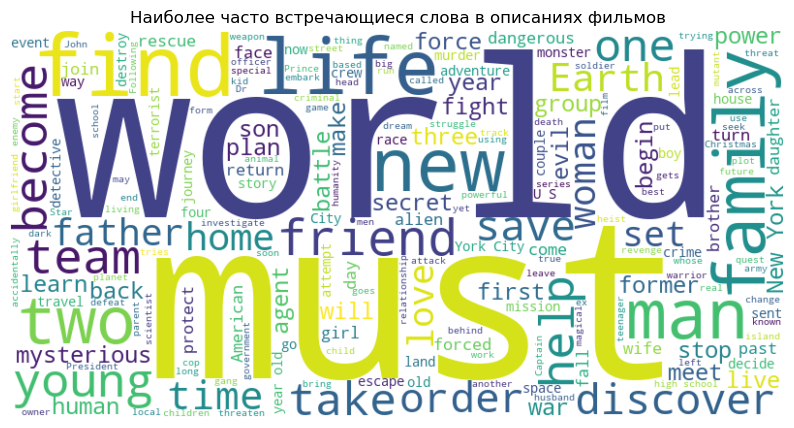

```python
# Объединение описаний фильмов в одну строку
descriptions = ' '.join(data['Movie Info'])

# Создание объекта WordCloud с настройками
wordcloud = WordCloud(width=800, height=400, background_color='white').generate(descriptions)

# Визуализация word cloud
plt.figure(figsize=(10, 6))
plt.imshow(wordcloud, interpolation='bilinear')
plt.axis('off')
plt.title('Наиболее часто встречающиеся слова в описаниях фильмов')
plt.show()
```

**Вывод:** Наиболее часто в описании к фильмам встречаются такие слова, как world, must, find, life, new, become, friend, young, team, help и тд.

### Построим ящик с усами для всех продаж

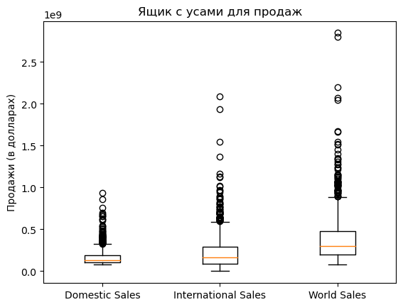

```python
# Создание списка с данными о продажах
sales_data = [data['Domestic Sales (in $)'], data['International Sales (in $)'], data['World Sales (in $)']]

# Создание ящика с усами
plt.boxplot(sales_data)

# Установка подписей для меток оси x
plt.xticks([1, 2, 3], ['Domestic Sales', 'International Sales', 'World Sales'])

# Установка подписи оси y
plt.ylabel('Продажи (в долларах)')

# Установка заголовка графика
plt.title('Ящик с усами для продаж')

# Отображение графика
plt.show()
```

```python
numm= ['Domestic Sales (in $)', 'International Sales (in $)', 'World Sales (in $)','Movie Runtime (min)']
catt= ['Title','Movie Info', 'Distributor','License','Genre']
datt='Release Date'
```

```python
data.columns
```

```
Index(['Unnamed: 0', 'Title', 'Movie Info', 'Distributor',
       'Domestic Sales (in $)', 'International Sales (in $)',
       'World Sales (in $)', 'Genre', 'License', 'Movie Runtime (min)',
       'Main Genre', 'Release Year', 'Duration Group'],
      dtype='object')
```

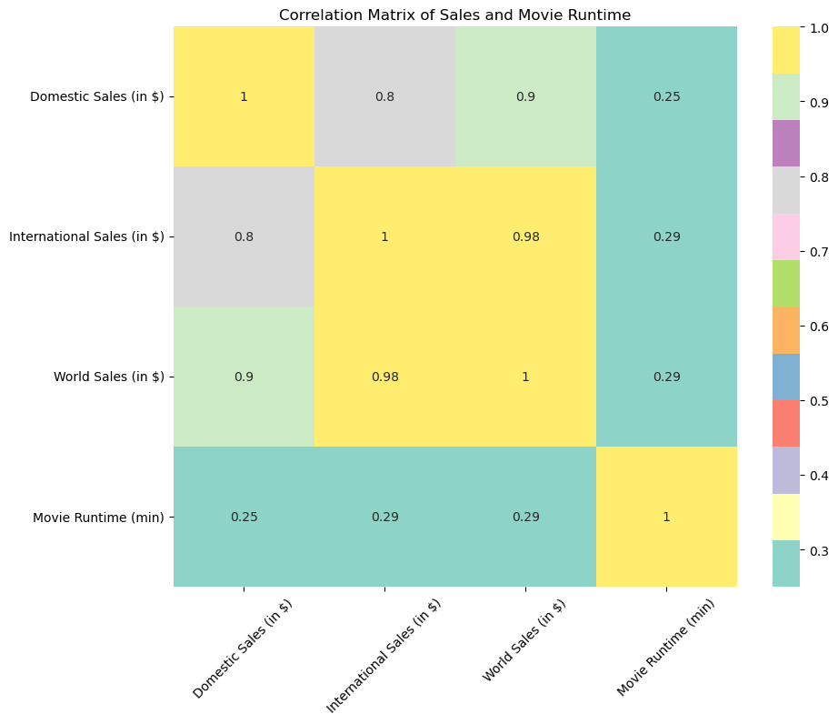

```python
# Выбираем нужные столбцы для анализа
data_correlation = data[['Domestic Sales (in $)', 'International Sales (in $)', 'World Sales (in $)', 'Movie Runtime (min)']]

# Создаем корреляционную матрицу
correlation_matrix = data_correlation.corr()

# Создаем тепловую карту корреляционной матрицы с цветовой палитрой Set2
plt.figure(figsize=(10, 8))
sns.heatmap(correlation_matrix, annot=True, cmap='Set3')

# Настройка внешнего вида графика
plt.title('Correlation Matrix of Sales and Movie Runtime')
plt.xticks(rotation=45)
plt.yticks(rotation=0)

# Отображаем график
plt.show()
```

**Вывод:** заметим, что внутренние и международные продажи имеют высокую положительную корреляцию с мировыми продажами, так как они суммируются с мировыми продажами. фильмы, которые набирают наибольшее число продаж внутри своей страны, набирают такие же высокие продажи и на мировом рынке.

### Построим гистограммы по всем видам продаж и длительности фильмов

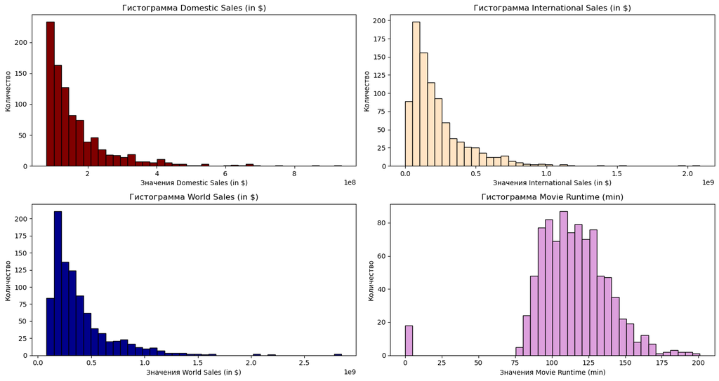

```python
fig, ax = plt.subplots(nrows=2, ncols=2, figsize=(15, 8))
ax_index = [ax[0, 0], ax[0, 1], ax[1, 0], ax[1, 1]]
colors = ['maroon','bisque','darkblue','plum']
for i in range(4):
    ax_index[i].hist(data[numm[i]], bins=40, color=colors[i], edgecolor='black')
    ax_index[i].set_title(f'Гистограмма {numm[i]}')
    ax_index[i].set_xlabel('Значения ' + numm[i])
    ax_index[i].set_ylabel('Количество')
fig.tight_layout()
plt.show()
```

**Вывод:** нетрудно заметить, что первые три графика смещены влево, в то время как последний график отличен от них, значит можно сделать вывод, что в данном случае присутвуют фильмы с млишким высоким уровнем продаж.

### Построим график, отобразив количество фильмов, снятых различными кинокомпаниями

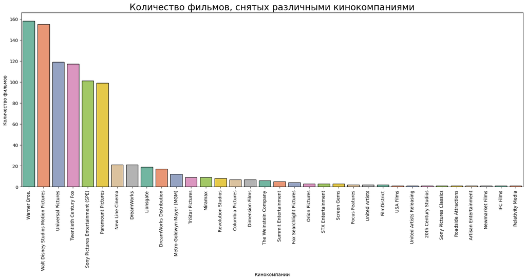

```python
fig, ax = plt.subplots(figsize=(20, 7))
sns.barplot(x='Distributor', y='Title', palette='Set2', edgecolor='black',
            data=data.groupby('Distributor', as_index=False)['Title'].count().sort_values('Title', ascending=False))
ax.tick_params(axis='x', labelrotation=90)
ax.set_title('Количество фильмов, снятых различными кинокомпаниями', fontsize=20)
ax.set_ylabel('Количество фильмов')
ax.set_xlabel('Кинокомпании')
plt.show()
```

### Построим график, отобразив количество мировых продаж по разным кинокомпаниям

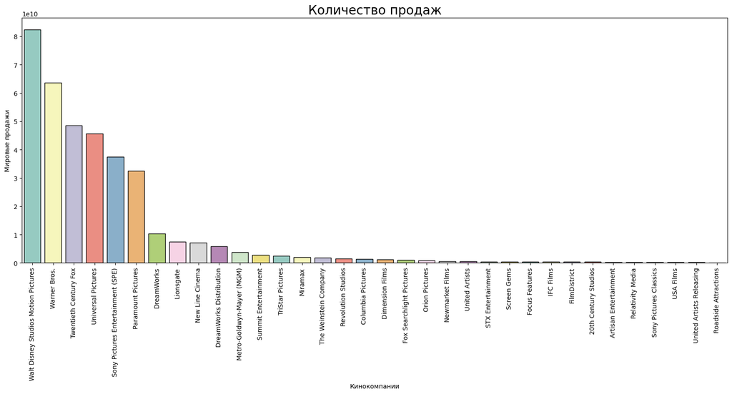

```python
fig,ax=plt.subplots(figsize=(20,7))
sns.barplot(x='Distributor',y='World Sales (in $)', palette='Set3', edgecolor='black',
            data= data.groupby('Distributor', as_index=False)['World Sales (in $)'].sum().sort_values('World Sales (in $)',ascending=False))
ax.tick_params(axis='x', labelrotation=90)
ax.set_ylabel('Мировые продажи')
ax.set_xlabel('Кинокомпании')
ax.set_title('Количество продаж', fontsize=20);
```

### Построим график, показывающий суммарные мировые продажи фильмов по годам

```python
max_release_date = data['Release Year'].max()
print(max_release_date)
```

```
2021
```

```python
# Преобразование столбца 'Release Year' в числовой тип данных
data['Release Year'] = data['Release Year'].astype(int)

# Создание интервалов годов
bins = [1937, 1990, 1994, 1998, 2002, 2006, 2010, 2014, 2018, 2021]
labels = ['1937-1989', '1990-1993', '1994-1997', '1998-2001', '2002-2005', '2006-2009', '2010-2013', '2014-2017', '2018-2021']
data['Year Group'] = pd.cut(data['Release Year'], bins=bins, labels=labels, right=False)

data['Year Group'] = pd.cut(data['Release Year'], bins=bins, labels=labels, right=False)

# Группировка данных по 'Year Group' и подсчет количества фильмов
grouped_sales_data = data.groupby('Year Group')['World Sales (in $)'].sum().reset_index(name='World Sales (in $)')

# Вывод таблицы
print(grouped_sales_data)
```

```
  Year Group  World Sales (in $)
0  1937-1989         10620456001
1  1990-1993         13287975511
2  1994-1997         20614445595
3  1998-2001         30365360010
4  2002-2005         40910077864
5  2006-2009         52349193555
6  2010-2013         67462321571
7  2014-2017         77883958716
8  2018-2021         43687894741
```

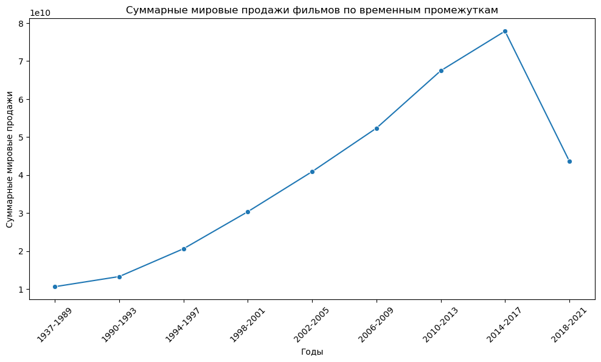

```python
# Convert 'World Sales (in $)' column to numeric data type
data['World Sales (in $)'] = pd.to_numeric(data['World Sales (in $)'], errors='coerce')

# Plot the line chart with trend line
plt.figure(figsize=(12, 6))
sns.lineplot(data=grouped_sales_data, x='Year Group', y='World Sales (in $)', marker='o',  palette='Set2')

# Set plot labels and title
plt.xlabel('Годы')
plt.ylabel('Суммарные мировые продажи')
plt.title('Cуммарные мировые продажи фильмов по временным промежуткам')

# Rotate x-axis labels for better readability
plt.xticks(rotation=45)

# Display the plot
plt.show()
```

**Вывод:** на графике отображается тренд, по которому видно,что до 2017 года включительно мировые продажи фильмов росли, однако позднее наблюдается спад.

# Шаг 5. Создание новых переменных

```python
# создание новой переменной Success
data['Success'] = data['World Sales (in $)'].apply(lambda x: 1 if x > 500 else 0)
data
```

|  | Unnamed: 0 | Title | Movie Info | Distributor | Domestic Sales (in $) | International Sales (in $) | World Sales (in $) | Genre | License | Movie Runtime (min) | Main Genre | Release Year | Duration Group | Year Group | Success |
| --- | --- | --- | --- | --- | --- | --- | --- | --- | --- | --- | --- | --- | --- | --- | --- |
| 0 | 0 | Star Wars: Episode VII - The Force Awakens (2015) | As a new threat to the galaxy rises, Rey, a de... | Walt Disney Studios Motion Pictures | 936662225 | 1132859475 | 2069521700 | ['Action', 'Adventure', 'Sci-Fi'] | PG-13 | 138 | Action | 2015 | 136-150 | 2014-2017 | 1 |
| 1 | 1 | Avengers: Endgame (2019) | After the devastating events of Avengers: Infi... | Walt Disney Studios Motion Pictures | 858373000 | 1939128328 | 2797501328 | ['Action', 'Adventure', 'Drama', 'Sci-Fi'] | PG-13 | 181 | Action | 2019 | >180 | 2018-2021 | 1 |
| 2 | 2 | Avatar (2009) | A paraplegic Marine dispatched to the moon Pan... | Twentieth Century Fox | 760507625 | 2086738578 | 2847246203 | ['Action', 'Adventure', 'Fantasy', 'Sci-Fi'] | PG-13 | 162 | Action | 2009 | 151-180 | 2006-2009 | 1 |
| 3 | 3 | Black Panther (2018) | T'Challa, heir to the hidden but advanced king... | Walt Disney Studios Motion Pictures | 700426566 | 647171407 | 1347597973 | ['Action', 'Adventure', 'Sci-Fi'] | NaN | 134 | Action | 2018 | 121-135 | 2018-2021 | 1 |
| 4 | 4 | Avengers: Infinity War (2018) | The Avengers and their allies must be willing ... | Walt Disney Studios Motion Pictures | 678815482 | 1369544272 | 2048359754 | ['Action', 'Adventure', 'Sci-Fi'] | NaN | 149 | Action | 2018 | 136-150 | 2018-2021 | 1 |
| ... | ... | ... | ... | ... | ... | ... | ... | ... | ... | ... | ... | ... | ... | ... | ... |
| 913 | 913 | The Notebook (2004) | A poor yet passionate young man falls in love ... | New Line Cinema | 81001787 | 36813370 | 117815157 | ['Drama', 'Romance'] | PG-13 | 123 | Drama | 2004 | 121-135 | 2002-2005 | 1 |
| 914 | 914 | Jimmy Neutron: Boy Genius (2001) | An eight-year-old boy genius and his friends m... | Paramount Pictures | 80936232 | 22056304 | 102992536 | ['Action', 'Adventure', 'Animation', 'Comedy',... | NaN | 82 | Action | 2001 | 76-90 | 1998-2001 | 1 |
| 915 | 915 | Eat Pray Love (2010) | A married woman realizes how unhappy her marri... | Sony Pictures Entertainment (SPE) | 80574010 | 124020006 | 204594016 | ['Biography', 'Drama', 'Romance'] | PG-13 | 133 | Biography | 2010 | 121-135 | 2010-2013 | 1 |
| 916 | 916 | The Texas Chainsaw Massacre (2003) | After picking up a traumatized young hitchhike... | New Line Cinema | 80571655 | 26792250 | 107363905 | ['Crime', 'Horror'] | R | 98 | Crime | 2003 | 91-105 | 2002-2005 | 1 |
| 917 | 917 | Zookeeper (2011) | A group of zoo animals decide to break their c... | Sony Pictures Entertainment (SPE) | 80360843 | 89491916 | 169852759 | ['Comedy', 'Family', 'Fantasy', 'Romance'] | PG | 102 | Comedy | 2011 | 91-105 | 2010-2013 | 1 |

918 rows × 15 columns

```python
data['Decade'] = ((data['Release Year'].astype(int) - 1) // 10 + 1) * 10

data.head()
```

|  | Unnamed: 0 | Title | Movie Info | Distributor | Domestic Sales (in $) | International Sales (in $) | World Sales (in $) | Genre | License | Movie Runtime (min) | Main Genre | Release Year | Duration Group | Year Group | Success | Decade |
| --- | --- | --- | --- | --- | --- | --- | --- | --- | --- | --- | --- | --- | --- | --- | --- | --- |
| 0 | 0 | Star Wars: Episode VII - The Force Awakens (2015) | As a new threat to the galaxy rises, Rey, a de... | Walt Disney Studios Motion Pictures | 936662225 | 1132859475 | 2069521700 | ['Action', 'Adventure', 'Sci-Fi'] | PG-13 | 138 | Action | 2015 | 136-150 | 2014-2017 | 1 | 2020 |
| 1 | 1 | Avengers: Endgame (2019) | After the devastating events of Avengers: Infi... | Walt Disney Studios Motion Pictures | 858373000 | 1939128328 | 2797501328 | ['Action', 'Adventure', 'Drama', 'Sci-Fi'] | PG-13 | 181 | Action | 2019 | >180 | 2018-2021 | 1 | 2020 |
| 2 | 2 | Avatar (2009) | A paraplegic Marine dispatched to the moon Pan... | Twentieth Century Fox | 760507625 | 2086738578 | 2847246203 | ['Action', 'Adventure', 'Fantasy', 'Sci-Fi'] | PG-13 | 162 | Action | 2009 | 151-180 | 2006-2009 | 1 | 2010 |
| 3 | 3 | Black Panther (2018) | T'Challa, heir to the hidden but advanced king... | Walt Disney Studios Motion Pictures | 700426566 | 647171407 | 1347597973 | ['Action', 'Adventure', 'Sci-Fi'] | NaN | 134 | Action | 2018 | 121-135 | 2018-2021 | 1 | 2020 |
| 4 | 4 | Avengers: Infinity War (2018) | The Avengers and their allies must be willing ... | Walt Disney Studios Motion Pictures | 678815482 | 1369544272 | 2048359754 | ['Action', 'Adventure', 'Sci-Fi'] | NaN | 149 | Action | 2018 | 136-150 | 2018-2021 | 1 | 2020 |

### 3. Создадим новую переменную Month, которая будет показывать, в каком месяце был выпущен фильм.

```python
data1 = pd.read_csv('h.csv')
# создание новой переменной Months
data['Months'] = pd.to_datetime(data1['Release Date'], errors='coerce').dt.month_name()

# замена пропущенных значений на None
data['Months'] = data['Months'].where(data['Months'].notnull(), None)
data
```

|  | Unnamed: 0 | Title | Movie Info | Distributor | Domestic Sales (in $) | International Sales (in $) | World Sales (in $) | Genre | License | Movie Runtime (min) | Main Genre | Release Year | Duration Group | Year Group | Success | Decade | Months |
| --- | --- | --- | --- | --- | --- | --- | --- | --- | --- | --- | --- | --- | --- | --- | --- | --- | --- |
| 0 | 0 | Star Wars: Episode VII - The Force Awakens (2015) | As a new threat to the galaxy rises, Rey, a de... | Walt Disney Studios Motion Pictures | 936662225 | 1132859475 | 2069521700 | ['Action', 'Adventure', 'Sci-Fi'] | PG-13 | 138 | Action | 2015 | 136-150 | 2014-2017 | 1 | 2020 | December |
| 1 | 1 | Avengers: Endgame (2019) | After the devastating events of Avengers: Infi... | Walt Disney Studios Motion Pictures | 858373000 | 1939128328 | 2797501328 | ['Action', 'Adventure', 'Drama', 'Sci-Fi'] | PG-13 | 181 | Action | 2019 | >180 | 2018-2021 | 1 | 2020 | April |
| 2 | 2 | Avatar (2009) | A paraplegic Marine dispatched to the moon Pan... | Twentieth Century Fox | 760507625 | 2086738578 | 2847246203 | ['Action', 'Adventure', 'Fantasy', 'Sci-Fi'] | PG-13 | 162 | Action | 2009 | 151-180 | 2006-2009 | 1 | 2010 | December |
| 3 | 3 | Black Panther (2018) | T'Challa, heir to the hidden but advanced king... | Walt Disney Studios Motion Pictures | 700426566 | 647171407 | 1347597973 | ['Action', 'Adventure', 'Sci-Fi'] | NaN | 134 | Action | 2018 | 121-135 | 2018-2021 | 1 | 2020 | None |
| 4 | 4 | Avengers: Infinity War (2018) | The Avengers and their allies must be willing ... | Walt Disney Studios Motion Pictures | 678815482 | 1369544272 | 2048359754 | ['Action', 'Adventure', 'Sci-Fi'] | NaN | 149 | Action | 2018 | 136-150 | 2018-2021 | 1 | 2020 | None |
| ... | ... | ... | ... | ... | ... | ... | ... | ... | ... | ... | ... | ... | ... | ... | ... | ... | ... |
| 913 | 913 | The Notebook (2004) | A poor yet passionate young man falls in love ... | New Line Cinema | 81001787 | 36813370 | 117815157 | ['Drama', 'Romance'] | PG-13 | 123 | Drama | 2004 | 121-135 | 2002-2005 | 1 | 2010 | June |
| 914 | 914 | Jimmy Neutron: Boy Genius (2001) | An eight-year-old boy genius and his friends m... | Paramount Pictures | 80936232 | 22056304 | 102992536 | ['Action', 'Adventure', 'Animation', 'Comedy',... | NaN | 82 | Action | 2001 | 76-90 | 1998-2001 | 1 | 2010 | December |
| 915 | 915 | Eat Pray Love (2010) | A married woman realizes how unhappy her marri... | Sony Pictures Entertainment (SPE) | 80574010 | 124020006 | 204594016 | ['Biography', 'Drama', 'Romance'] | PG-13 | 133 | Biography | 2010 | 121-135 | 2010-2013 | 1 | 2010 | August |
| 916 | 916 | The Texas Chainsaw Massacre (2003) | After picking up a traumatized young hitchhike... | New Line Cinema | 80571655 | 26792250 | 107363905 | ['Crime', 'Horror'] | R | 98 | Crime | 2003 | 91-105 | 2002-2005 | 1 | 2010 | October |
| 917 | 917 | Zookeeper (2011) | A group of zoo animals decide to break their c... | Sony Pictures Entertainment (SPE) | 80360843 | 89491916 | 169852759 | ['Comedy', 'Family', 'Fantasy', 'Romance'] | PG | 102 | Comedy | 2011 | 91-105 | 2010-2013 | 1 | 2020 | July |

918 rows × 17 columns

# Шаг 6. Гипотезы

### Гипотеза 1: Фильмы, выпущенные в летний сезон, имеют более высокую кассовую выручку, чем фильмы, выпущенные в другое время года:

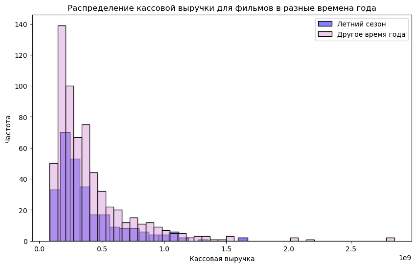

```python
# создание двух выборок: фильмы, выпущенные в летний сезон, и фильмы, выпущенные в другое время года
summer_movies = data[data['Months'].isin(['June', 'July', 'August'])]['World Sales (in $)']
other_movies = data[~data['Months'].isin(['June', 'July', 'August'])]['World Sales (in $)']

# Визуализация распределения
plt.figure(figsize=(10, 6))
sns.histplot(summer_movies, color='blue', alpha=0.5, label='Летний сезон')
sns.histplot(other_movies, color='plum', alpha=0.5, label='Другое время года')
plt.xlabel('Кассовая выручка')
plt.ylabel('Частота')
plt.title('Распределение кассовой выручки для фильмов в разные времена года')
plt.legend()
plt.show()
```

```python
# Распределение переменных не похоже на нормальное. Будем использовать непараметрический тест Манна-Уитни.

# Проверка гипотезы с помощью теста Манна-Уитни
statistic, p_value = stats.mannwhitneyu(summer_movies, other_movies)

print('Статистика U:', statistic)
print('p-значение:', p_value)

if p_value < 0.05:
    print("Вывод: гипотеза отвергается, то есть нет значимой разницы в кассовой выручке между фильмами, выпущенными в летний сезон, и фильмами, выпущенными в другое время года")
else:
    print("Вывод: гипотеза не отвергается, то есть фильмы, выпущенные в летний сезон, имеют более высокую кассовую выручку, чем фильмы, выпущенные в другое время года")
```

[output not shown]

### Гипотеза 2: длительность фильмов в 20 веке меньше длительности фильмов в 21 веке:

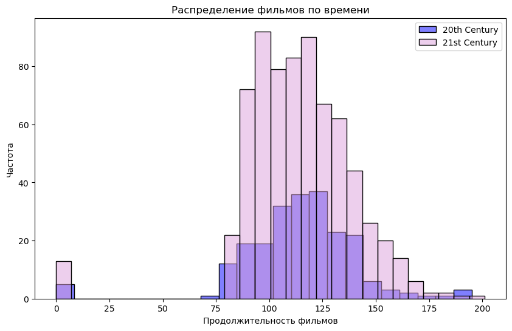

```python
# Фильтрация данных для 20-го века
films_20th = data[data['Release Year'].between(1900, 2000)]

# Фильтрация данных для 21-го века
films_21st = data[data['Release Year'].between(2001, 2100)]

# Визуализация распределения
plt.figure(figsize=(10, 6))
sns.histplot(films_20th['Movie Runtime (min)'], label='20th Century', color='blue', alpha=0.5)
sns.histplot(films_21st['Movie Runtime (min)'], label='21st Century', color='plum', alpha=0.5)
plt.xlabel('Продолжительность фильмов')
plt.ylabel('Частота')
plt.title('Распределение фильмов по времени')
plt.legend()
plt.show()
```

```python
# Поскольку распределение похоже на нормальное, используем t-тест Стьюдента для проверки гипотезы

t_statistic, p_value = stats.ttest_ind(films_20th['Movie Runtime (min)'], films_21st['Movie Runtime (min)'], equal_var=False)

# Вывод результата t-теста
print('t-Statistic:', t_statistic)
print('p-Value:', p_value)
if p_value < 0.05:
    print("Вывод: Гипотеза о том, что длительность фильмов в 20 веке меньше длительности фильмов в 21 веке отвергается")
else:
    print("Вывод: Гипотеза о том, что длительность фильмов в 20 веке меньше длительности фильмов в 21 веке не отвергается")
```

```
t-Statistic: 0.18225112964577336
p-Value: 0.8554896403111893
Вывод: Гипотеза о том, что длительность фильмов в 20 веке меньше длительности фильмов в 21 веке не отвергается
```

### Гипотеза 3 в среднем продажи фильмов, вышедших после 2000 года выше, чем до 2000 года

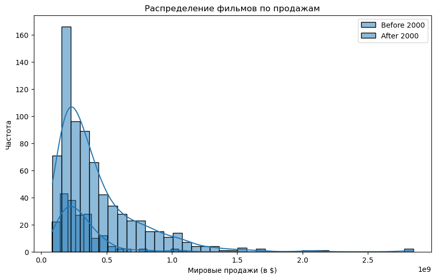

```python
# Создание двух выборок: фильмы до 2000 года и фильмы после 2000 года
sales_before_2000 = data[data['Release Year'] < 2000]['World Sales (in $)']
sales_after_2000 = data[data['Release Year'] >= 2000]['World Sales (in $)']

# График распределения
plt.figure(figsize=(10, 6))
sns.histplot(sales_before_2000, label='Before 2000', kde=True)
sns.histplot(sales_after_2000, label='After 2000', kde=True)
plt.xlabel('Мировые продажи (в $)')
plt.ylabel('Частота')
plt.title('Распределение фильмов по продажам')
plt.legend()
plt.show()
```

```python
# Распределение переменных не похоже на нормальное. Будем использовать непараметрический тест Манна-Уитни.

from scipy.stats import mannwhitneyu
# Применение теста Манна-Уитни
statistic, p_value = mannwhitneyu(sales_before_2000, sales_after_2000, alternative='less')

# Вывод результатов
print('Mann-Whitney U statistic:', statistic)
print('P-value:', p_value)

# Проверка статистической значимости
alpha = 0.05  # Уровень значимости

if p_value < 0.05:
    print("Вывод: Гипотеза о том, что в среднем продажи фильмов, вышедших после 2000 года выше, чем до 2000 года отвергается")
else:
    print("Вывод: Гипотеза о том, что в среднем продажи фильмов, вышедших после 2000 года выше, чем до 2000 года не отвергается")
```

[output not shown]

### Машинное обучение:

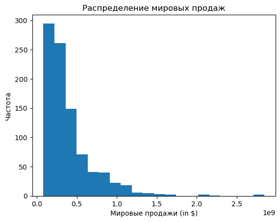

```python
# Построим диаграмму распределения мировых продаж фильмов
plt.hist(data['World Sales (in $)'], bins=20)
plt.xlabel('Мировые продажи (in $)')
plt.ylabel('Частота')
plt.title('Распределение мировых продаж')
plt.show()
```

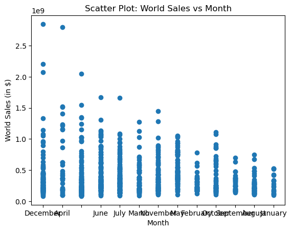

```python
# Заменить значения None на пустую строку
data['Months'] = data['Months'].fillna('')

# Преобразовать значения столбца Months в тип строка (str)
data['Months'] = data['Months'].astype(str)

# Диаграмма рассеивания между "World Sales (in $)" и "Month"
plt.scatter(data['Months'], data['World Sales (in $)'])
plt.xlabel('Month')
plt.ylabel('World Sales (in $)')
plt.title('Scatter Plot: World Sales vs Month')
plt.show()
```

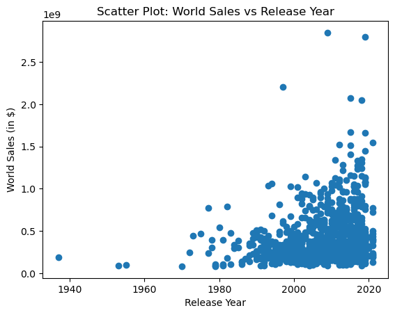

```python
# Диаграмма рассеивания между "World Sales (in $)" и "Release Year"
plt.scatter(data['Release Year'], data['World Sales (in $)'])
plt.xlabel('Release Year')
plt.ylabel('World Sales (in $)')
plt.title('Scatter Plot: World Sales vs Release Year')
plt.show()
```

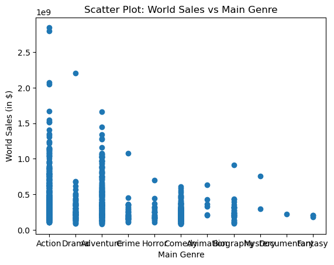

```python
# Диаграмма рассеивания между "World Sales (in $)" и "Main Genre"
plt.scatter(data['Main Genre'], data['World Sales (in $)'])
plt.xlabel('Main Genre')
plt.ylabel('World Sales (in $)')
plt.title('Scatter Plot: World Sales vs Main Genre')
plt.show()
```

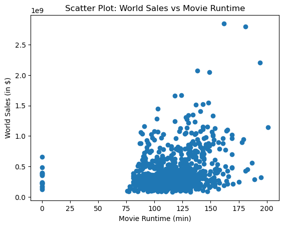

```python
# Диаграмма рассеивания между "World Sales (in $)" и "Movie Runtime (min)"
plt.scatter(data['Movie Runtime (min)'], data['World Sales (in $)'])
plt.xlabel('Movie Runtime (min)')
plt.ylabel('World Sales (in $)')
plt.title('Scatter Plot: World Sales vs Movie Runtime')
plt.show()
```

[figure not shown]

```python
# Заменить значения None на пустую строку
data['License'] = data['License'].fillna('')

# Преобразовать значения столбца License в тип строка (str)
data['License'] = data['License'].astype(str)

# Диаграмма рассеивания между "World Sales (in $)" и "License"
plt.scatter(data['License'], data['World Sales (in $)'])
plt.xlabel('License')
plt.ylabel('World Sales (in $)')
plt.title('Scatter Plot: World Sales vs License')
plt.show()
```

```python
from sklearn.linear_model import LinearRegression
from sklearn.preprocessing import OneHotEncoder
from sklearn.compose import ColumnTransformer

movies_df = pd.read_csv('h.csv')

# удаление пропущенных значений
movies_df.dropna(subset=['Domestic Sales (in $)'], inplace=True)
movies_df.dropna(subset=['World Sales (in $)'], inplace=True)
movies_df.dropna(subset=['Genre'], inplace=True)
movies_df.dropna(subset=['Distributor'], inplace=True)

# выбор релевантных фичей
features = ['Domestic Sales (in $)', 'Genre', 'Distributor']

# создание фич и таргет
X = movies_df[features]
y = movies_df['World Sales (in $)']

# преобразование категориальных переменных в числовые
ct = ColumnTransformer(transformers=[('encoder', OneHotEncoder(), ['Genre', 'Distributor'])], remainder='passthrough')
X = ct.fit_transform(X)

# создание модели
model = LinearRegression()
model.fit(X, y)

# предсказание
predicted = model.predict(X)

# оценка модели
score = model.score(X, y)
print(f"Коэффицент детерминации: {score:.2f}")
```

```
Коэффицент детерминации: 0.82
```

```python
# разделение на тренировочный и тестовый наборы данных
from sklearn.model_selection import train_test_split

X_train, X_test, y_train, y_test = train_test_split(X, y, test_size=0.2, random_state=42)

# обучение модели линейной регрессии
lr = LinearRegression()
lr.fit(X_train, y_train)

# оценка точности модели на тренировочном и тестовом наборах данных
train_score = lr.score(X_train, y_train)
test_score = lr.score(X_test, y_test)

print('Train R^2 score:', train_score)
print('Test R^2 score:', test_score)
```

```
Train R^2 score: 0.8263954879388201
Test R^2 score: 0.7749986443813135
```

```python
from sklearn.metrics import r2_score
r2_score(y_test, lr.predict(X_test))
```

```
0.7749986443813135
```

```python
from sklearn.metrics import mean_squared_error
mse = mean_squared_error(y_test, lr.predict(X_test))
mse
```

```
1.7146041669750976e+16
```

```python
from sklearn.metrics import mean_absolute_error
mae = mean_absolute_error(y_test, lr.predict(X_test))
mae
```

```
96080298.34592845
```

```python
rmse = np.sqrt(mse)
rmse
```

```
130942894.68982643
```

[figure not shown]